# Mini Project 1 – Exploratory Data Analysis (EDA)

## Introduction

Each row in the dataset represents one individual record, such as a single customer, transaction, or observation. The columns represent different attributes or features related to that record, such as numerical values, categories, or timestamps.

The goal of this phase is to inspect the dataset structure, understand the data types, and review basic statistics before performing any cleaning or analysis.

```python
import pandas as pd
```

```python
df = pd.read_csv(r"D:\MCA\4TH MCA\DS_AI_Internship\src\Day 20\customer_analytics.csv")
```

```python
df.head()
```

|  | CustomerID | Age | Gender | City | Education | MaritalStatus | AnnualIncome | SpendingScore | YearsEmployed | PurchaseFrequency | OnlineVisitsPerMonth | ReturnedItems | PreferredDevice | LastPurchaseAmount |
| --- | --- | --- | --- | --- | --- | --- | --- | --- | --- | --- | --- | --- | --- | --- |
| 0 | 1001 | 49 | Male | Pune | Masters | Single | 82953.0 | 66 | 23 | 19 | 9 | 2 | Laptop | 3944 |
| 1 | 1002 | 44 | Male | Pune | PhD | Single | 60610.0 | 56 | 22 | 1 | 23 | 3 | Desktop | 3885 |
| 2 | 1003 | 42 | Male | Mumbai | Bachelors | Single | 35501.0 | 44 | 18 | 10 | 29 | 3 | Laptop | 3247 |
| 3 | 1004 | 36 | Female | Mumbai | Masters | Married | 99312.0 | 36 | 10 | 12 | 21 | 3 | Mobile | 2028 |
| 4 | 1005 | 23 | Male | Pune | Masters | Married | 46980.0 | 56 | 1 | 18 | 9 | 3 | Tablet | 1100 |

```python
df.info()
```

```
<class 'pandas.core.frame.DataFrame'>
RangeIndex: 255 entries, 0 to 254
Data columns (total 14 columns):
 #   Column                Non-Null Count  Dtype
---  ------                --------------  -----
 0   CustomerID            255 non-null    int64
 1   Age                   255 non-null    int64
 2   Gender                255 non-null    object
 3   City                  255 non-null    object
 4   Education             243 non-null    object
 5   MaritalStatus         255 non-null    object
 6   AnnualIncome          243 non-null    float64
 7   SpendingScore         255 non-null    int64
 8   YearsEmployed         255 non-null    int64
 9   PurchaseFrequency     255 non-null    int64
 10  OnlineVisitsPerMonth  255 non-null    int64
 11  ReturnedItems         255 non-null    int64
 12  PreferredDevice       255 non-null    object
 13  LastPurchaseAmount    255 non-null    int64
dtypes: float64(1), int64(8), object(5)
memory usage: 28.0+ KB
```

```python
df.describe()
```

|  | CustomerID | Age | AnnualIncome | SpendingScore | YearsEmployed | PurchaseFrequency | OnlineVisitsPerMonth | ReturnedItems | LastPurchaseAmount |
| --- | --- | --- | --- | --- | --- | --- | --- | --- | --- |
| count | 255.000000 | 255.000000 | 243.000000 | 255.000000 | 255.000000 | 255.000000 | 255.000000 | 255.000000 | 255.00000 |
| mean | 1126.941176 | 37.729412 | 74499.901235 | 45.721569 | 14.682353 | 11.568627 | 16.078431 | 1.858824 | 2795.07451 |
| std | 72.397256 | 9.767842 | 43939.855655 | 17.869522 | 9.651664 | 7.077899 | 7.909536 | 1.409917 | 1328.77241 |
| min | 1001.000000 | 21.000000 | 16062.000000 | 5.000000 | 1.000000 | 1.000000 | 3.000000 | 0.000000 | 566.00000 |
| 25% | 1064.500000 | 29.000000 | 56353.000000 | 34.500000 | 6.000000 | 5.000000 | 10.000000 | 1.000000 | 1542.50000 |
| 50% | 1128.000000 | 38.000000 | 69629.000000 | 47.000000 | 15.000000 | 11.000000 | 16.000000 | 2.000000 | 2705.00000 |
| 75% | 1190.500000 | 46.000000 | 84030.500000 | 57.500000 | 23.000000 | 18.000000 | 23.000000 | 3.000000 | 4001.00000 |
| max | 1250.000000 | 54.000000 | 474327.000000 | 95.000000 | 34.000000 | 24.000000 | 29.000000 | 4.000000 | 4996.00000 |

```python
print("Shape:", df.shape)
print("Columns:", df.columns)
```

```
Shape: (255, 14)
Columns: Index(['CustomerID', 'Age', 'Gender', 'City', 'Education', 'MaritalStatus',
       'AnnualIncome', 'SpendingScore', 'YearsEmployed', 'PurchaseFrequency',
       'OnlineVisitsPerMonth', 'ReturnedItems', 'PreferredDevice',
       'LastPurchaseAmount'],
      dtype='object')
```

# Phase 2 – Data Preprocessing (Cleanup)

## Objective

The goal of this phase is to clean the dataset and make it reliable for analysis. This includes identifying missing values, handling them appropriately, and removing duplicate records.

Cleaning data is important because missing or duplicate values can lead to incorrect analysis and misleading results.

```python
df.isnull().sum()
```

```
CustomerID               0
Age                      0
Gender                   0
City                     0
Education               12
MaritalStatus            0
AnnualIncome            12
SpendingScore            0
YearsEmployed            0
PurchaseFrequency        0
OnlineVisitsPerMonth     0
ReturnedItems            0
PreferredDevice          0
LastPurchaseAmount       0
dtype: int64
```

```python
(df.isnull().sum() / len(df)) * 100
```

```
CustomerID              0.000000
Age                     0.000000
Gender                  0.000000
City                    0.000000
Education               4.705882
MaritalStatus           0.000000
AnnualIncome            4.705882
SpendingScore           0.000000
YearsEmployed           0.000000
PurchaseFrequency       0.000000
OnlineVisitsPerMonth    0.000000
ReturnedItems           0.000000
PreferredDevice         0.000000
LastPurchaseAmount      0.000000
dtype: float64
```

## Missing Value Treatment Decision

Columns with very few missing values were filled using appropriate methods such as mean (for numerical data) or mode (for categorical data).

If any column had a very high percentage of missing values (more than 50%), it would be dropped because it would not provide reliable information.

This ensures the dataset remains accurate while preserving useful information.

```python
df.fillna(df.mean(numeric_only=True), inplace=True)
```

```python
df.fillna(df.mode().iloc[0], inplace=True)
```

```python
df.duplicated().sum()
```

```
5
```

```python
df.drop_duplicates(inplace=True)
```

## Duplicate Removal Decision

Duplicate rows were removed to ensure each record represents a unique customer. Keeping duplicates could bias the analysis and produce incorrect insights.

```python
df.info()
```

```
<class 'pandas.core.frame.DataFrame'>
Index: 250 entries, 0 to 249
Data columns (total 14 columns):
 #   Column                Non-Null Count  Dtype
---  ------                --------------  -----
 0   CustomerID            250 non-null    int64
 1   Age                   250 non-null    int64
 2   Gender                250 non-null    object
 3   City                  250 non-null    object
 4   Education             250 non-null    object
 5   MaritalStatus         250 non-null    object
 6   AnnualIncome          250 non-null    float64
 7   SpendingScore         250 non-null    int64
 8   YearsEmployed         250 non-null    int64
 9   PurchaseFrequency     250 non-null    int64
 10  OnlineVisitsPerMonth  250 non-null    int64
 11  ReturnedItems         250 non-null    int64
 12  PreferredDevice       250 non-null    object
 13  LastPurchaseAmount    250 non-null    int64
dtypes: float64(1), int64(8), object(5)
memory usage: 29.3+ KB
```

# Phase 3 – Univariate and Bivariate Analysis

## Objective

The goal of this phase is to explore individual variables and relationships between variables using data visualization techniques.

Univariate analysis focuses on understanding the distribution of a single variable, such as Age or AnnualIncome, using histograms and bar charts. This helps identify common values, spread, and possible outliers.

Bivariate analysis examines relationships between two variables, such as AnnualIncome and SpendingScore, using scatter plots and boxplots. This helps identify trends, patterns, and differences between customer groups.

```python
import matplotlib.pyplot as plt
import seaborn as sns
sns.set_style("whitegrid")
```

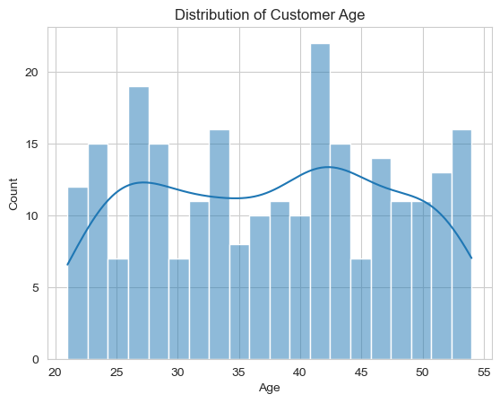

```python
plt.figure()
sns.histplot(df['Age'], bins=20, kde=True)
plt.title("Distribution of Customer Age")
plt.xlabel("Age")
plt.ylabel("Count")
plt.show()
```

**Explanation:** The histogram shows how customer ages are distributed. It helps identify the most common age group and whether the data is skewed toward younger or older customers.

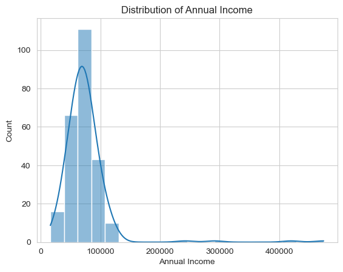

```python
plt.figure()
sns.histplot(df['AnnualIncome'], bins=20, kde=True)
plt.title("Distribution of Annual Income")
plt.xlabel("Annual Income")
plt.ylabel("Count")
plt.show()
```

**Explanation:** This histogram with KDE curve shows how customer annual income is distributed. It helps identify the most common income ranges and whether the distribution is skewed toward lower or higher incomes.

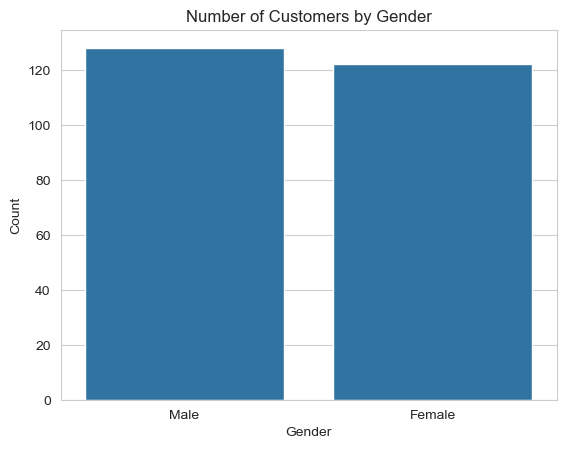

```python
plt.figure()
sns.countplot(x='Gender', data=df)
plt.title("Number of Customers by Gender")
plt.xlabel("Gender")
plt.ylabel("Count")
plt.show()
```

**Explanation:** This bar chart shows the number of male and female customers. It helps understand the gender composition of the dataset.

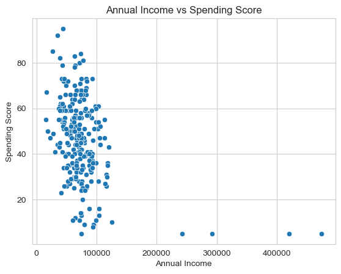

```python
plt.figure()
sns.scatterplot(x='AnnualIncome', y='SpendingScore', data=df)
plt.title("Annual Income vs Spending Score")
plt.xlabel("Annual Income")
plt.ylabel("Spending Score")
plt.show()
```

**Explanation:** This scatter plot shows the relationship between income and spending score. It helps determine whether higher-income customers tend to spend more.

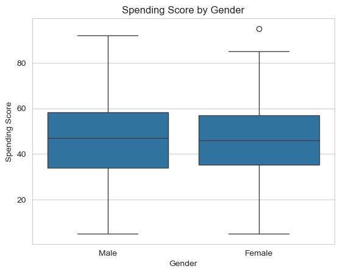

```python
plt.figure()
sns.boxplot(x='Gender', y='SpendingScore', data=df)
plt.title("Spending Score by Gender")
plt.xlabel("Gender")
plt.ylabel("Spending Score")
plt.show()
```

**Explanation:** This boxplot compares spending behavior between genders. It shows differences in median spending and highlights any outliers.

```python
corr_matrix = df.corr(numeric_only=True)
corr_matrix
```

|  | CustomerID | Age | AnnualIncome | SpendingScore | YearsEmployed | PurchaseFrequency | OnlineVisitsPerMonth | ReturnedItems | LastPurchaseAmount |
| --- | --- | --- | --- | --- | --- | --- | --- | --- | --- |
| CustomerID | 1.000000 | -0.038170 | -0.039649 | 0.070869 | -0.018877 | -0.077040 | -0.029642 | 0.023180 | -0.034412 |
| Age | -0.038170 | 1.000000 | -0.051910 | -0.006943 | 0.975242 | 0.103053 | -0.033532 | -0.051190 | 0.092891 |
| AnnualIncome | -0.039649 | -0.051910 | 1.000000 | -0.386146 | -0.054428 | -0.037018 | 0.092756 | -0.113211 | -0.015953 |
| SpendingScore | 0.070869 | -0.006943 | -0.386146 | 1.000000 | -0.017487 | 0.009792 | -0.072441 | 0.057686 | 0.032737 |
| YearsEmployed | -0.018877 | 0.975242 | -0.054428 | -0.017487 | 1.000000 | 0.073113 | -0.052168 | -0.050904 | 0.114464 |
| PurchaseFrequency | -0.077040 | 0.103053 | -0.037018 | 0.009792 | 0.073113 | 1.000000 | -0.041362 | 0.084121 | -0.068246 |
| OnlineVisitsPerMonth | -0.029642 | -0.033532 | 0.092756 | -0.072441 | -0.052168 | -0.041362 | 1.000000 | -0.071400 | 0.010528 |
| ReturnedItems | 0.023180 | -0.051190 | -0.113211 | 0.057686 | -0.050904 | 0.084121 | -0.071400 | 1.000000 | 0.016208 |
| LastPurchaseAmount | -0.034412 | 0.092891 | -0.015953 | 0.032737 | 0.114464 | -0.068246 | 0.010528 | 0.016208 | 1.000000 |

# Phase 4 – Multivariate Analysis and Storytelling

## Objective

The purpose of this phase is to analyze relationships among multiple variables simultaneously and summarize key findings.

A correlation matrix and heatmap were used to identify strong and weak relationships between numerical variables such as income, spending score, and purchase frequency.

The insights gained from this analysis help understand customer behavior patterns and provide valuable information that can support business decision-making and marketing strategies.

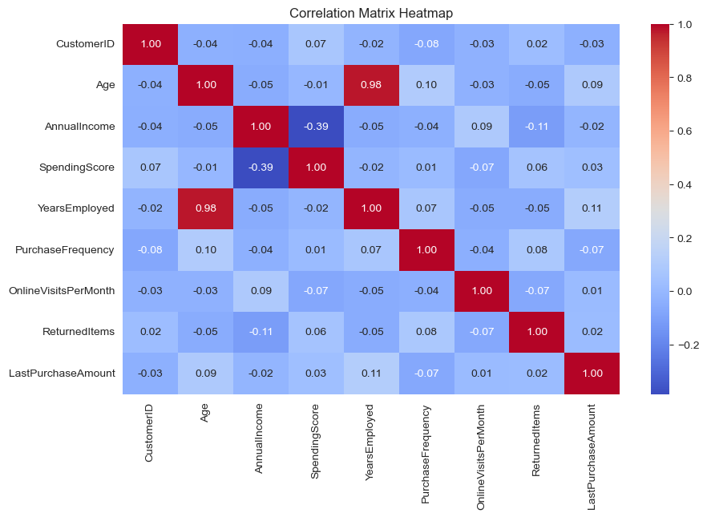

```python
import matplotlib.pyplot as plt
import seaborn as sns

plt.figure(figsize=(10,6))
sns.heatmap(corr_matrix, annot=True, cmap="coolwarm", fmt=".2f")
plt.title("Correlation Matrix Heatmap")
plt.show()
```

## Correlation Heatmap Explanation

The heatmap shows the relationships between numerical variables such as Age, AnnualIncome, SpendingScore, and PurchaseFrequency. Darker colors indicate stronger relationships. This helps identify which variables influence customer spending behavior the most.

# Executive Summary

Overall, the analysis provides valuable insights into customer demographics and spending patterns, which can help businesses improve marketing strategies and customer targeting.